# Las Vegas Hotel Reviews Analysis

Findings are summarized in the table below:

**Summary of key features:**

[output not shown]

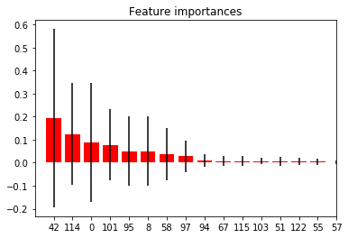

```python
# Plot the feature importances of the forest in order of importance
plt.figure()
plt.title("Feature importances")
plt.bar(range(Xtrain.shape[1]), feature_importance[indices],
       color="r", yerr=std[indices], align="center")
plt.xticks(range(Xtrain.shape[1]), indices)
plt.xlim([-1, 15])
plt.show()
```

**Feature importance ranking**

We should note that these key features have very high inter-trees variability! Some trees may have these features while many other trees may not use all of these features. If I create more trees, I may decrease the inter-trees variability and the feature importance ranking may change. I suspect that features such as “User country_USA”, “User country_Canada” and “User continent_North America” will move up in ranking while “User country_Singapore” will probably drop.

**Feature dependence**

After analyzing and summarizing the key features in one table, I realize that many features are correlated.

1. “User country_USA” and “User country_Canada” are correlated with “User continent_North America”. I should probably remove “User continent” altogether because “User country” is sufficient for my use case. The rank-1 feature is only 0.193413. Removing duplicate features or redundant features will remove the number of zeros in the data set. A less-sparse data set should help me to narrow down to the truly important features.
2. “Hotel stars_3” and “Hotel stars_4”: These features are also associated. I should combine them into one binary feature by giving 4-star and 5-star a value of 1 and 3-star below a value of 0 to reduce the number of zeros in the data set.

**False positives**

Search and score with validation error can handle dependence and context-specific relevance problems of feature selection. Using validation score as metric, I did identify these dependence issues. However, this approach is prone to false positives. I suspect that features such as “User country_Singapore” and “User continent_Asia” are examples of false positives due to tiny effects.

**Correlation not causality**

I should remind myself that the key features only suggest correlation not causality. I cannot overinterpret my result and tell my buddies that these are the reasons why a hotel gets high scores. In order to prove causality, I will have to design an experiment such as a randomized controlled trial.

**Domain expert input**

As per DSCI 573 lecture notes, Dr. Schmidt suggested that domain expert inputs would often be the key to the true answers. I should probably consult travel blogs and check their Las Vegas recommendations against my own findings.

**Coupon collecting problem**

I started with 19 features and 504 data instances. It is a good ratio there because I have 26 times more data than my features. However, when I convert the categorical variables to dummy variables, I have 126 features versus 504 data instances. Dr. Schmidt recommended that the data instances should be at least 10 times more than the features. Not having enough data for the corresponding number of features, I cannot let my model learn all the possible combinations of my features. The coupon-collecting problem is evident in this analysis.

**Take-home message**

I will share my findings with my buddies but I will warn them that the analysis is definitely far from perfect!

```python
%%bash

pip freeze
```

[output not shown]

[output cut: 146 more lines]

[output not shown]